# Assignment5_Krausman_Zachary

Zachary Krausman

2026-03-24

Install relevant packages (if needed), load them, open the raw data set

```r
# install.packages("tidyverse")
# install.packages("here")
# install.packages("pacman")
# install.packages("cowplot")
# install.packages("viridis")

# OR
pacman::p_load(tidyverse, here, cowplot, viridis, car)

raw_fish <- read_csv(here("data", "raw", "pond_fish_body_morpho.csv"))
```

Create a new data object that utilizes the raw data and transforms some of it into a new column called body_condition

```r
fish_condition <- raw_fish %>%
  mutate(body_condition = mass_g / length_mm) %>%
  filter(!is.na(body_condition)) %>%

  select(site, sci_name, common_name, length_mm, mass_g, body_condition)

# selects for specific columns in the fish_condition object and runs summary stats on them
summary(fish_condition[c("length_mm", "mass_g", "body_condition")])
```

```
##    length_mm         mass_g      body_condition
##  Min.   :100.0   Min.   :38.26   Min.   :0.3688
##  1st Qu.:113.8   1st Qu.:50.91   1st Qu.:0.4335
##  Median :119.8   Median :55.22   Median :0.4583
##  Mean   :119.7   Mean   :55.22   Mean   :0.4610
##  3rd Qu.:124.7   3rd Qu.:59.95   3rd Qu.:0.4936
##  Max.   :145.3   Max.   :74.08   Max.   :0.5485
```

Testing to see if the body condition of fish differed among species in pond_a by running an ANOVA and getting summary stats

```r
# sci_name and common_name both reflect the same computed values for x
fish_anova <- aov(body_condition ~ common_name, data = fish_condition)

# prints out our summary statistics
summary(fish_anova)
```

```
##              Df  Sum Sq Mean Sq F value Pr(>F)
## common_name   2 0.17503 0.08752   153.7 <2e-16 ***
## Residuals   172 0.09795 0.00057
## ---
## Signif. codes:  0 '***' 0.001 '**' 0.01 '*' 0.05 '.' 0.1 ' ' 1
```

```r
# this prints out our sum of squares, deg. of freedom, & residual standard error
print(fish_anova)
```

```
## Call:
##    aov(formula = body_condition ~ common_name, data = fish_condition)
##
## Terms:
##                 common_name  Residuals
## Sum of Squares   0.17503431 0.09794792
## Deg. of Freedom           2        172
##
## Residual standard error: 0.02386346
## Estimated effects may be unbalanced
```

The anova descriptive statistic results are **F(2, 172) = 153.7, p = 2e-16**. The p value is highly significant which means that there is a significant difference between body condition size among the three species of fish.

Since our anova had a significant p-value, we run a Tukey Test to see which species significantly differed from each other for body condition.

```r
TukeyHSD(fish_anova)
```

```
##   Tukey multiple comparisons of means
##     95% family-wise confidence level
##
## Fit: aov(formula = body_condition ~ common_name, data = fish_condition)
##
## $common_name
##                                   diff         lwr         upr p adj
## Redbreast sunfish-Bluegill  0.04837591  0.03865795  0.05809387     0
## Warmouth-Bluegill          -0.03073998 -0.04207760 -0.01940235     0
## Warmouth-Redbreast sunfish -0.07911588 -0.09029819 -0.06793358     0
```

The p adj value is 0 for every species comparison has a significant difference in body condition size. If I understand this properly, the redbreast sunfish has the largest body_condition (mass (g) per length (mm)) compared to the other two species.

Diagnostic plots to check and see if our anova meets the correct assumptions and normality is adequate

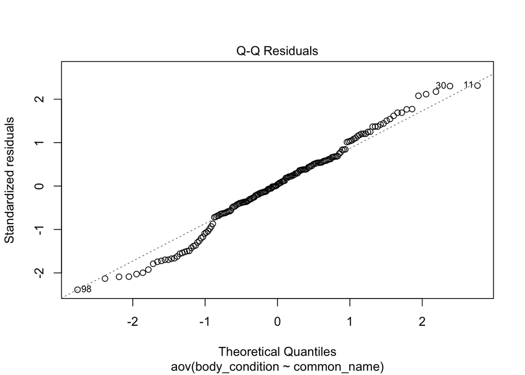

```r
# QQ plot
plot(fish_anova, which = 2)
```

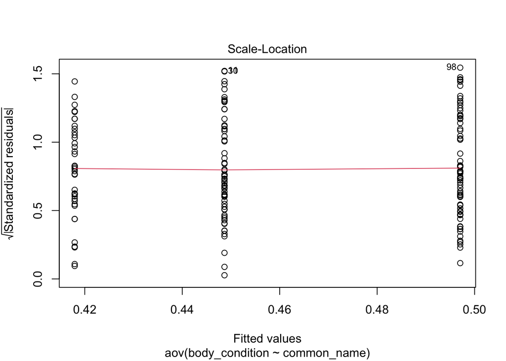

```r
# scale-location plot
plot(fish_anova, which = 3)
```

```r
# Levene test
leveneTest(fish_anova)
```

```
## Levene's Test for Homogeneity of Variance (center = median)
##        Df F value Pr(>F)
## group   2  0.1035 0.9018
##       172
```

For an Anova, we have 3 assumptions: our observations are obtained independently and randomly which we have to follow for this case, the data are normally distributed which we see is roughly normally distributed from our QQ plot and the circles following the diagonal line (mostly), and the populations in each group have a common variance, which they appear to from the distinct sepearation of categories on the scale-location graph. The Levene test for this categorical test shows that we have common variance since our Pr value is greater than 0.05 (we fail to reject the null hypothesis that variance is equal among groups).

Making the linear model for overall fish mass with respect to body length

```r
# linear model for fish mass based on known body length
fish_regression <- lm(mass_g ~ length_mm, data = fish_condition)

summary(fish_regression)
```

```
##
## Call:
## lm(formula = mass_g ~ length_mm, data = fish_condition)
##
## Residuals:
##      Min       1Q   Median       3Q      Max
## -10.2803  -3.1280  -0.4475   3.7589  10.3408
##
## Coefficients:
##             Estimate Std. Error t value Pr(>|t|)
## (Intercept) -5.66209    5.13416  -1.103    0.272
## length_mm    0.50852    0.04278  11.888   <2e-16 ***
## ---
## Signif. codes:  0 '***' 0.001 '**' 0.01 '*' 0.05 '.' 0.1 ' ' 1
##
## Residual standard error: 4.726 on 173 degrees of freedom
## Multiple R-squared:  0.4496, Adjusted R-squared:  0.4464
## F-statistic: 141.3 on 1 and 173 DF,  p-value: < 2.2e-16
```

```r
# correlation
cor_value <- cor(x = fish_condition$length_mm,
                 y = fish_condition$mass_g)

# the little r for the slope of the line of best fit
print(cor_value)
```

```
## [1] 0.6705186
```

```r
cor_value^2
```

```
## [1] 0.4495952
```

**F(1, 173) = 141.3, p = 2.2e-16**. There is a significant predictive relationship for length_mm since the p value is much lower than 0.05. However, the correlation value of 0.67 means that it is positively correlated, but not extremely correlated. Additionally the R^2 value is a little low so the line of best fit doesn’t fit the data the best.

Creating the diagnostic plots for linear model based on correct assumptions

- Observations are independent of each other
- There is a linear relationship between x and y
- Values of model residuals are normally distributed
- Variance of model residuals is the same across all values of x

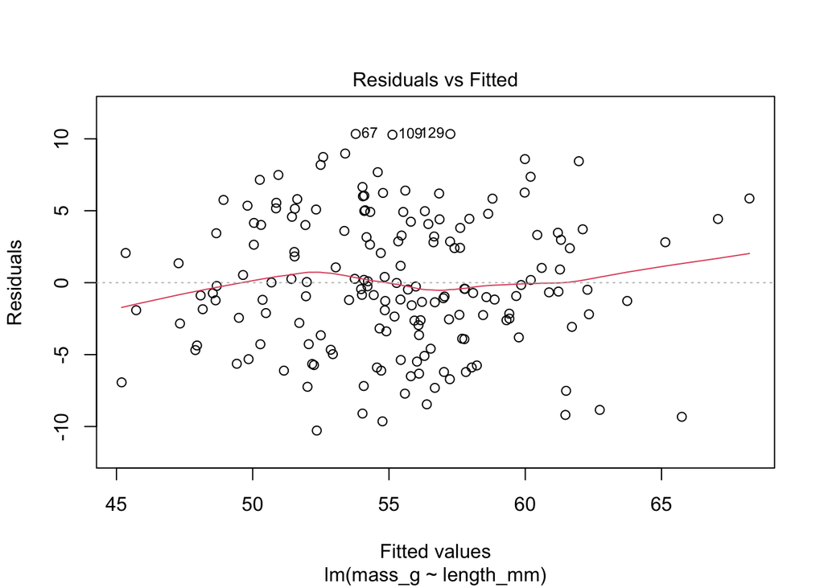

```r
# Residuals vs. fitted plot
plot(fish_regression, which = 1)
```

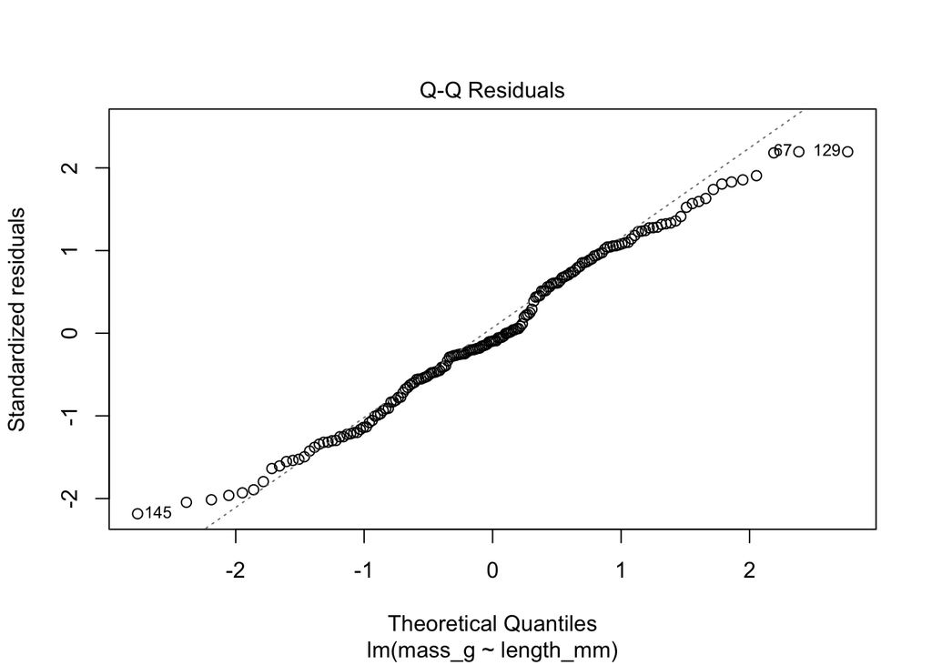

```r
# QQ test for normality
plot(fish_regression, which = 2)
```

```r
# shapiro test for normality
shapiro.test(fish_regression$residuals)
```

```
##
##  Shapiro-Wilk normality test
##
## data:  fish_regression$residuals
## W = 0.98601, p-value = 0.07838
```

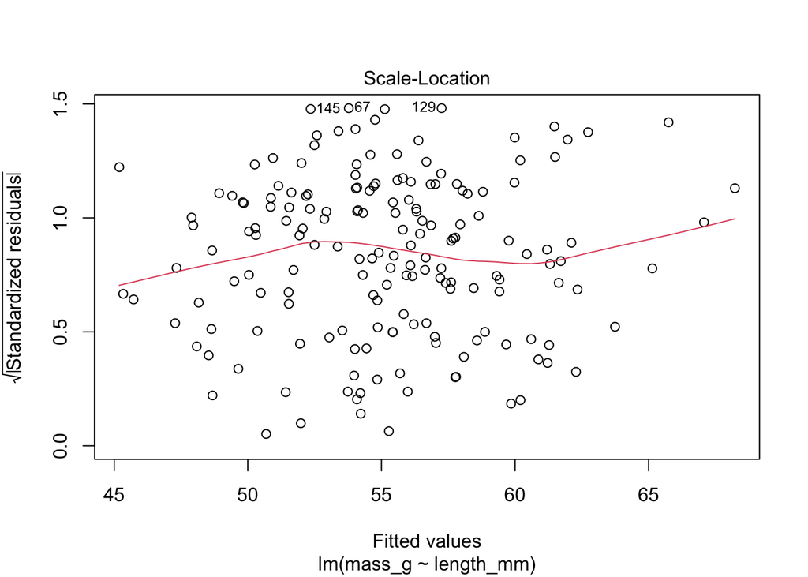

```r
# Scale-Location plot for variance
plot(fish_regression, which = 3)
```

Visualizing the patterns in the ANOVA and linear model

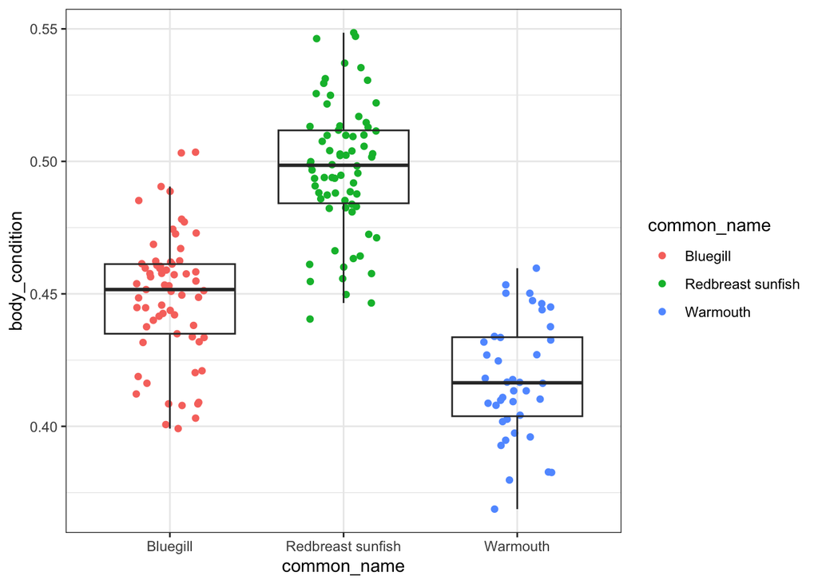

```r
# ANOVA plot body condition data by species
ggplot(data = fish_condition,
         aes(x = common_name,
             y = body_condition)) +
  geom_jitter(aes(col = common_name),
              width = 0.2) +
  geom_boxplot(fill = NA,
               outlier.shape = NA) +
  theme_bw()
```

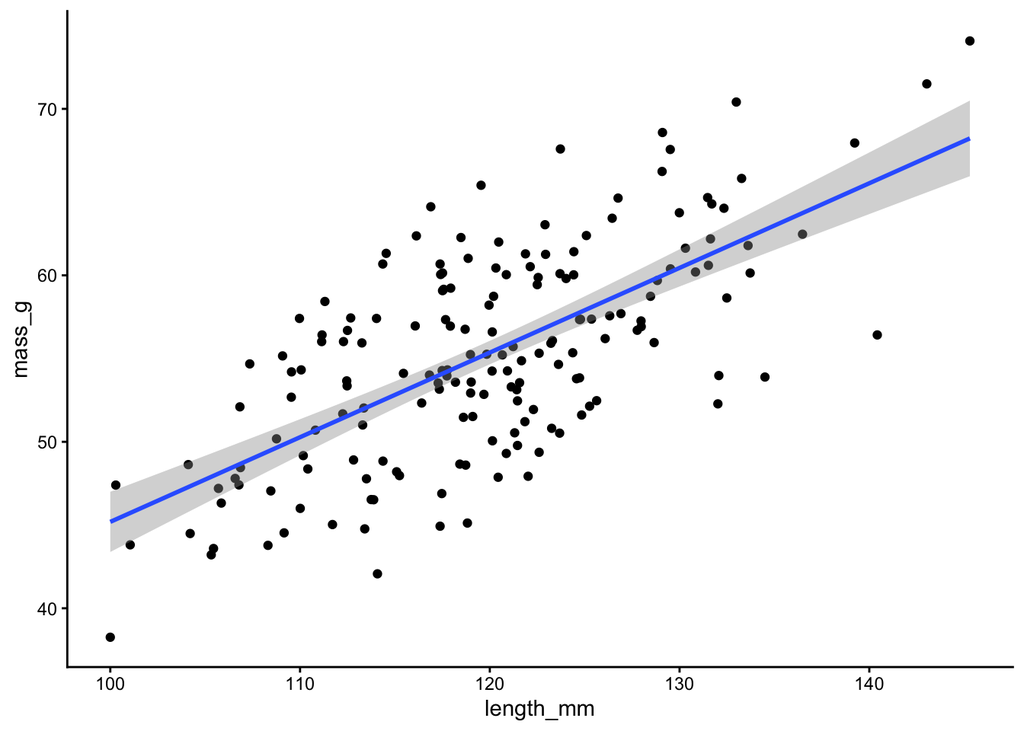

```r
# graph for linear model
ggplot(data = fish_condition,
       aes(x = length_mm,
           y = mass_g)) +
  geom_point() +
  theme_classic() +

  # put a linear best fit line
  geom_smooth(method = "lm")
```

These graphs help aid the significant findings from both the ANOVA and linear model tests (in fact I used them to double check the written values from above before even creating this chunk) and make them more readable and easy to understand. The ecological takehome message is that there is a significant difference between body condition (g/mm) between fish species and that fish mass (g) is positively correlated with fish size (mm). After working through and learning a lot of the basics again, I feel better than I did with the statistical tests, but it is still a lot to remember and not all of the diagnostic read-outs and summary stats feel super clear which means making the plotted graphs were also confusing at times (plus learning what the syntax for everything is and what it does was a bit confusing at times too) - I feel like I sit at a 3.